# Trabajo MADII - Análisis multivariante de un conjunto de datos

Ahora, vamos a aplicar la función principal para hacer todo lo anterior de una manera mucho más cómoda y sencilla.

Antes, cargamos los datos en X para mayor completitud.

```r
X <- good_reads[variables_numericas]
```

Comenzamos como antes, con dos factores y sin rotación.

```r
mt_af <- principal(X, nfactors = 2, rotate = "none")
mt_af
```

```
## Principal Components Analysis
## Call: principal(r = X, nfactors = 2, rotate = "none")
## Standardized loadings (pattern matrix) based upon correlation matrix
##                         PC1   PC2     h2    u2 com
## author_average_rating  0.23  0.92 0.8920 0.108 1.1
## author_rating_count    0.85 -0.11 0.7424 0.258 1.0
## author_review_count    0.87 -0.11 0.7761 0.224 1.0
## book_average_rating    0.24  0.92 0.9021 0.098 1.1
## num_ratings            0.83 -0.16 0.7137 0.286 1.1
## num_reviews            0.83 -0.16 0.7137 0.286 1.1
## pages                  0.15  0.15 0.0455 0.954 2.0
## publish_year          -0.04 -0.02 0.0021 0.998 1.3
##
##                        PC1  PC2
## SS loadings           3.00 1.78
## Proportion Var        0.38 0.22
## Cumulative Var        0.38 0.60
## Proportion Explained  0.63 0.37
## Cumulative Proportion 0.63 1.00
##
## Mean item complexity =  1.2
## Test of the hypothesis that 2 components are sufficient.
##
## The root mean square of the residuals (RMSR) is  0.09
##  with the empirical chi square  10244.77  with prob <  0
##
## Fit based upon off diagonal values = 0.93
```

```r
mt_af$values
```

```
## [1] 3.00435164 1.78337705 1.02217250 0.96878278 0.76576972 0.22257614 0.18520800
## [8] 0.04776218
```

```r
mt_af$loadings
```

```
##
## Loadings:
##                       PC1    PC2
## author_average_rating  0.232  0.916
## author_rating_count    0.855 -0.111
## author_review_count    0.875 -0.105
## book_average_rating    0.236  0.920
## num_ratings            0.829 -0.162
## num_reviews            0.830 -0.159
## pages                  0.148  0.153
## publish_year
##
##                  PC1   PC2
## SS loadings    3.004 1.783
## Proportion Var 0.376 0.223
## Cumulative Var 0.376 0.598
```

```r
mt_af$communality
```

```
## author_average_rating   author_rating_count   author_review_count
##           0.891984007           0.742438709           0.776118317
##   book_average_rating           num_ratings           num_reviews
##           0.902070696           0.713721191           0.713721169
##                 pages          publish_year
##           0.045527161           0.002147438
```

Vamos a volver a mostrar las comunalidades y ver si las dos variables que tenían baja comunlaidad efectivamente mejorar si aumentamos el número de factores.

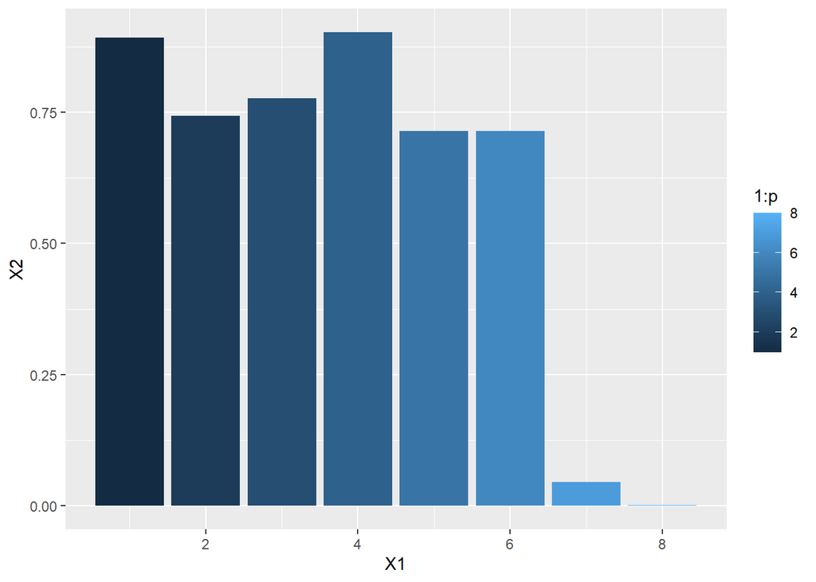

```r
ggplot(data.frame(cbind(1:p, mt_af$communality)), aes(x = X1, y = X2, fill=1:p)) +
  geom_bar(stat='identity')
```

Vemos que estas las variables relativas al año de publicación y número de páginas vuelven a tener poca comunalidad. De nuevo, vamos a aumentar el número de factores en pos de que mejoren.

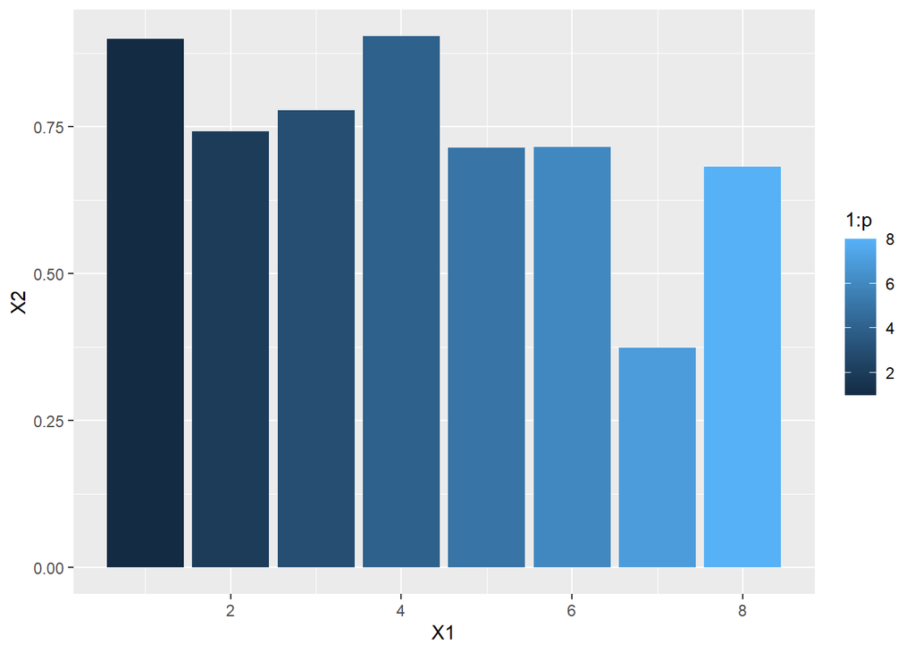

Como podemos comprobar, ahora sí que tenemos bajas unicidades, el número de páginas sigue teniendo una comunalidad baja, pero en general hemos mejorado estos números.

Podríamos seguir aumentando el número de factores, y con ello mejorarían las comunalidades; pero esto conllevaría un desequilibrío, ya que nuestro objetivo es minimizar el número de estos.

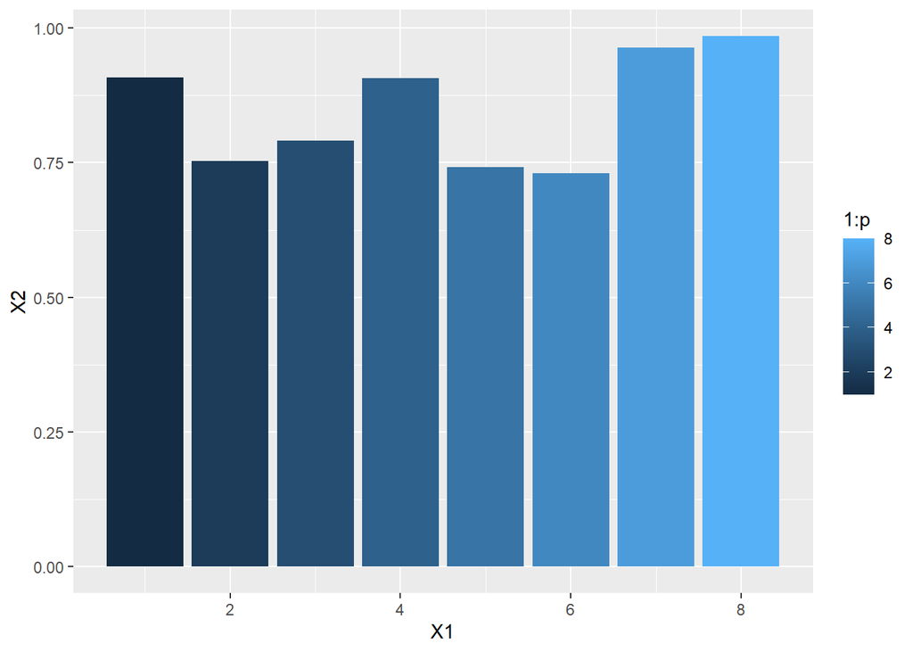

Como podemos comprobar, con 4 factores ninguna variable tiene la comunalidad baja. No obstante, decidimos quedarnos con 3 para tratar de encontrar un equilibrio. Como hemos decidido quedarnos con tres factores, vamos a mostrar de nuevo para estos los valores de cada variable:

```r
mt_af_3$loadings
```

```
##
## Loadings:
##                       PC1    PC2    PC3
## author_average_rating  0.232  0.916
## author_rating_count    0.855 -0.111
## author_review_count    0.875 -0.105
## book_average_rating    0.236  0.920
## num_ratings            0.829 -0.162
## num_reviews            0.830 -0.159
## pages                  0.148  0.153 -0.574
## publish_year                         0.825
##
##                  PC1   PC2   PC3
## SS loadings    3.004 1.783 1.022
## Proportion Var 0.376 0.223 0.128
## Cumulative Var 0.376 0.598 0.726
```

Vemos que el primer factor hace referencia de nuevo a la popularidad, el segundo a el nivel o aprobación media y el tercero a libros con pocas páginas y recientes, que puede tener sentido para encontrar aquellos libros que son más o menos modernos y que no tienen una gran cantidad de páginas.

Manera directa:

```r
mt_af_3$complexity
```

```
## author_average_rating   author_rating_count   author_review_count
##              1.145751              1.033532              1.032973
##   book_average_rating           num_ratings           num_reviews
##              1.135114              1.076481              1.080292
##                 pages          publish_year
##              1.283560              1.006317
```

Manera artesanal:

```r
indice_Hoffman <- function(x) (sum(x^2)^2)/sum(x^4)
comp <- apply(mt_af_3$loadings, 1, indice_Hoffman)
comp
```

```
## author_average_rating   author_rating_count   author_review_count
##              1.145751              1.033532              1.032973
##   book_average_rating           num_ratings           num_reviews
##              1.135114              1.076481              1.080292
##                 pages          publish_year
##              1.283560              1.006317
```

Calculamos la complejidad media.

```r
mean(comp)
```

```
## [1] 1.099252
```

Como vemos, tenemos una complejidad media de 1, lo que es casi perfecto. En general, vemos que casi todas las variables tienen una complejidad cercana a 1, siendo las más altas “pages” y “author_average_rating”.

Vemos cómo aportan cada una de las variables a cada factor con la siguiente función.

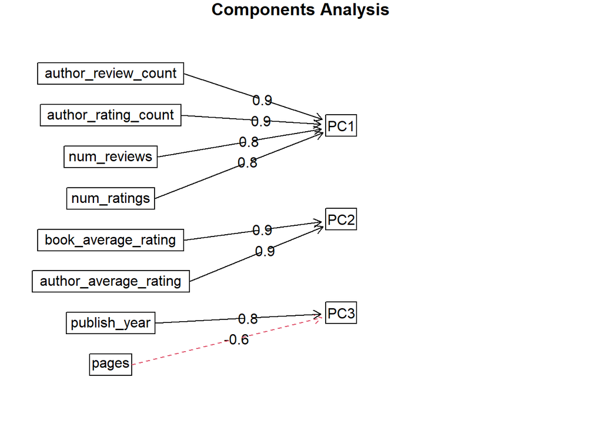

```r
fa.diagram(mt_af_3)
```

Por último, vamos a mostrar las comunalidades pero aplicando la rotación varimax.

```r
mt_af_3R <- principal(X, nfactors = 3)
mt_af_3R
```

```
## Principal Components Analysis
## Call: principal(r = X, nfactors = 3)
## Standardized loadings (pattern matrix) based upon correlation matrix
##                        RC1  RC2   RC3   h2    u2 com
## author_average_rating 0.05 0.95 -0.02 0.90 0.101 1.0
## author_rating_count   0.86 0.06 -0.06 0.74 0.258 1.0
## author_review_count   0.88 0.07 -0.03 0.78 0.222 1.0
## book_average_rating   0.05 0.95 -0.07 0.90 0.096 1.0
## num_ratings           0.84 0.01 -0.04 0.71 0.286 1.0
## num_reviews           0.85 0.01 -0.01 0.72 0.284 1.0
## pages                 0.08 0.12 -0.60 0.37 0.625 1.1
## publish_year          0.02 0.07  0.82 0.68 0.318 1.0
##
##                        RC1  RC2  RC3
## SS loadings           2.95 1.82 1.04
## Proportion Var        0.37 0.23 0.13
## Cumulative Var        0.37 0.60 0.73
## Proportion Explained  0.51 0.31 0.18
## Cumulative Proportion 0.51 0.82 1.00
##
## Mean item complexity =  1
## Test of the hypothesis that 3 components are sufficient.
##
## The root mean square of the residuals (RMSR) is  0.12
##  with the empirical chi square  18799.86  with prob <  0
##
## Fit based upon off diagonal values = 0.88
```

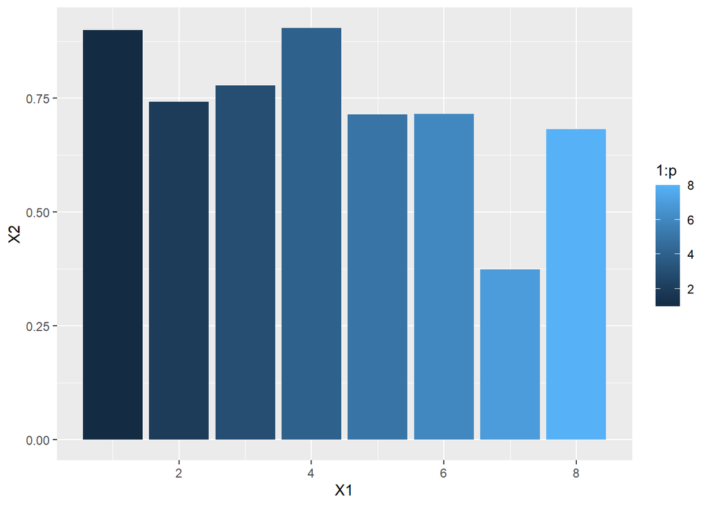

Vemos que prácticamente no varía al aplicar esta rotación. Mostramos el digrama de mayor carga para cada variable.

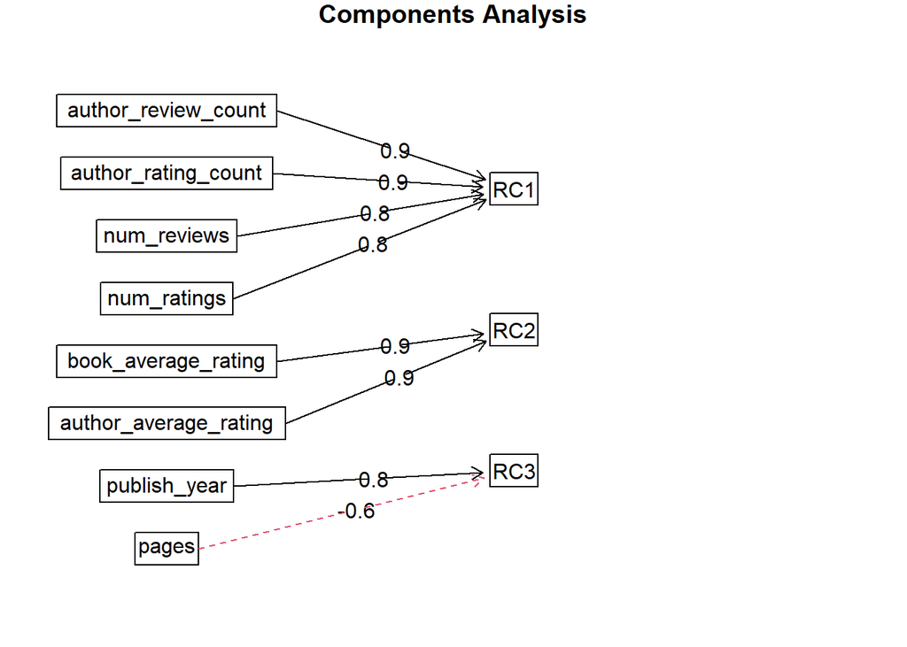

```r
fa.diagram(mt_af_3R)
```

Como último apartado, vamos a comprobar los residuos de un análisis con una sola componente, para ver si es suficiente o no.

```r
L_1 <- (rep(1, p) %*% t(sqrt(Rprop$values[1:1]))) * Rprop$vectors[, 1:1]
h2_1 <- rowSums(L_1^2)
psi_1 <- 1 - h2_1
D_1 <- R - (L_1 %*%t(L_1) + diag(psi_1))
sum(D_1^2)
```

```
## [1] 1.773347
```

Vemos el error para dos factores.

```r
sum(D^2)
```

```
## [1] 0.4475456
```

Como podemos comprobar, efectivamente no sería un buen ajuste, ya que obtenemos residuos muy altos.

## 4. Análisis de Conglomerados (AC)

En este apartado realizaremos un Análisis de Conglomerados, y para esto aplicaremos el método de las K-medias.

Importamos los paquetes.

```r
if(!require(ggplot2)){
  install.packages("ggplot2")
  require(ggplot2)
}
```

Importamos los datos.

```r
ruta_read_rda <- "../Datos/Procesados/good_reads_final_preprocesado.rda"
load(file = ruta_read_rda)
```

Ejecutamos la identificación e imputación de los valors nulos.

```r
apply(good_reads, 2, function(x) return(sum(is.na(x))))
```

```
## author_average_rating         author_gender         author_genres
##                     0                     0                     0
##   author_rating_count   author_review_count            birthplace
##                     0                     0                  4449
##   book_average_rating               genre_1               genre_2
##                     0                     0                     0
##           num_ratings           num_reviews                 pages
##                     0                     0                     3
##                 score          publish_year
##                     0                   743
```

```r
good_reads$pages[is.na(good_reads$pages)] <- mean(good_reads$pages, na.rm=TRUE)
good_reads$publish_year[is.na(good_reads$publish_year)] <- median(good_reads$publish_year, na.rm=TRUE)
```

Volvemos a realizar la selección de variables numéricas.

```r
variables_numericas <- c("author_average_rating",
                         "author_rating_count",
                         "author_review_count",
                         "book_average_rating",
                         "num_ratings",
                         "num_reviews",
                         "pages",
                         "publish_year")
```

Para poder mostrar los resultados, evidentemente, necesitamos dos dimensiones. Para conseguirlas, vamos a recuperar los resultados obtenidos del apartado 2 análisis de componentes principales, y así poder proyectar nuestros datos a dos dimensiones.

```r
X <- good_reads[variables_numericas]
df_pca <- prcomp(X, scale. = TRUE)
X_pca <- data.frame(df_pca$x[, 1:2])
```

Primero, al igual que vimos en la práctica informática, vamos a aplicar el método iterativo para comprobar cómo se van recalculando los centroides y con ello reagrupando los puntos.

Mostramos los puntos.

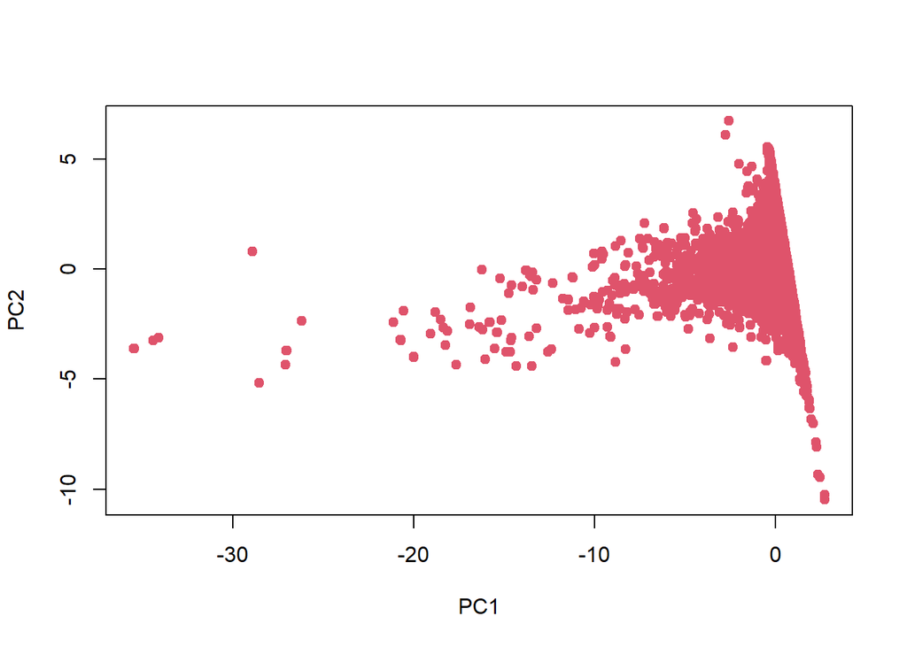

Seleccionamos el número de grupos. Lo haremos con k=2.

```r
K <- 2
```

Vamos a fijar una semilla.

```r
set.seed(123)
```

Calculamos los centroides inicales.

```r
centroides <- X_pca[sample(dim(X_pca)[1], K), ]
rownames(centroides) <- 1:K
centroides
```

```
##         PC1       PC2
## 1 0.3074988 0.7352864
## 2 0.4197099 0.9309116
```

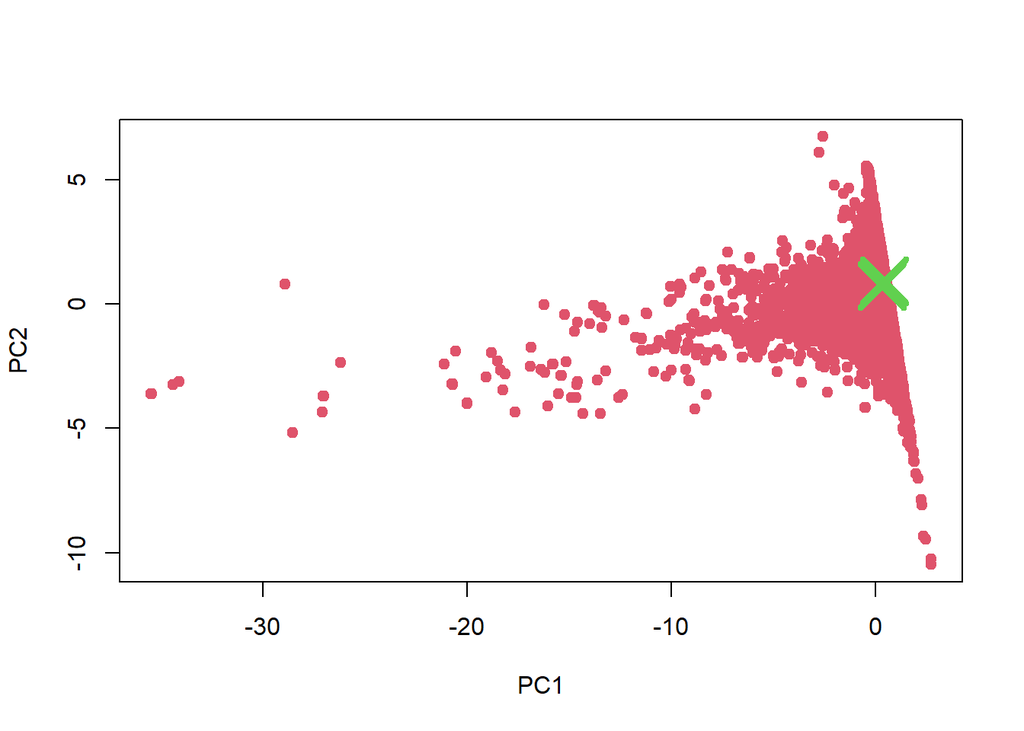

Vemos que los dos centroides han caído entre la “masa” donde se aglomeran casi todos los puntos.

- Primera iteración:

```r
for(i in 1:K){
  txt <- paste("X_pca$distancia",
               i,
               "<- sqrt((X_pca$PC1 - centroides$PC1[",
               i,
               "])^2 + (X_pca$PC2 - centroides$PC2[",
               i,
               "])^2)",
               sep = "")
  eval(parse(text = txt))
}
head(X_pca)
```

```
##           PC1        PC2 distancia1 distancia2
## 1   0.3467795  0.3573941  0.3799283  0.5781359
## 2 -15.8129542 -2.4020199 16.4229015 16.5712950
## 3   0.3103740  0.2929278  0.4423679  0.6472848
## 4   0.4865715  0.3904216  0.3885856  0.5446099
## 5  -0.1657911  0.5328196  0.5147777  0.7080174
## 6   0.6877414 -0.9366709  1.7146503  1.8867181
```

Asignación de clúster; aquel cuyo centroide esté más cerca.

```r
X_pca$cluster <- apply(X_pca[, 3:(2 + K)], 1, which.min)
head(X_pca)
```

```
##           PC1        PC2 distancia1 distancia2 cluster
## 1   0.3467795  0.3573941  0.3799283  0.5781359       1
## 2 -15.8129542 -2.4020199 16.4229015 16.5712950       1
## 3   0.3103740  0.2929278  0.4423679  0.6472848       1
## 4   0.4865715  0.3904216  0.3885856  0.5446099       1
## 5  -0.1657911  0.5328196  0.5147777  0.7080174       1
## 6   0.6877414 -0.9366709  1.7146503  1.8867181       1
```

Actualización de centroides:

```r
centroides <- aggregate(cbind(PC1, PC2) ~ cluster,
                        data = X_pca,
                        mean)
centroides
```

```
##   cluster        PC1        PC2
## 1       1 -0.0322653 -0.4681299
## 2       2  0.1169739  1.6971483
```

Mostramos los resultados:

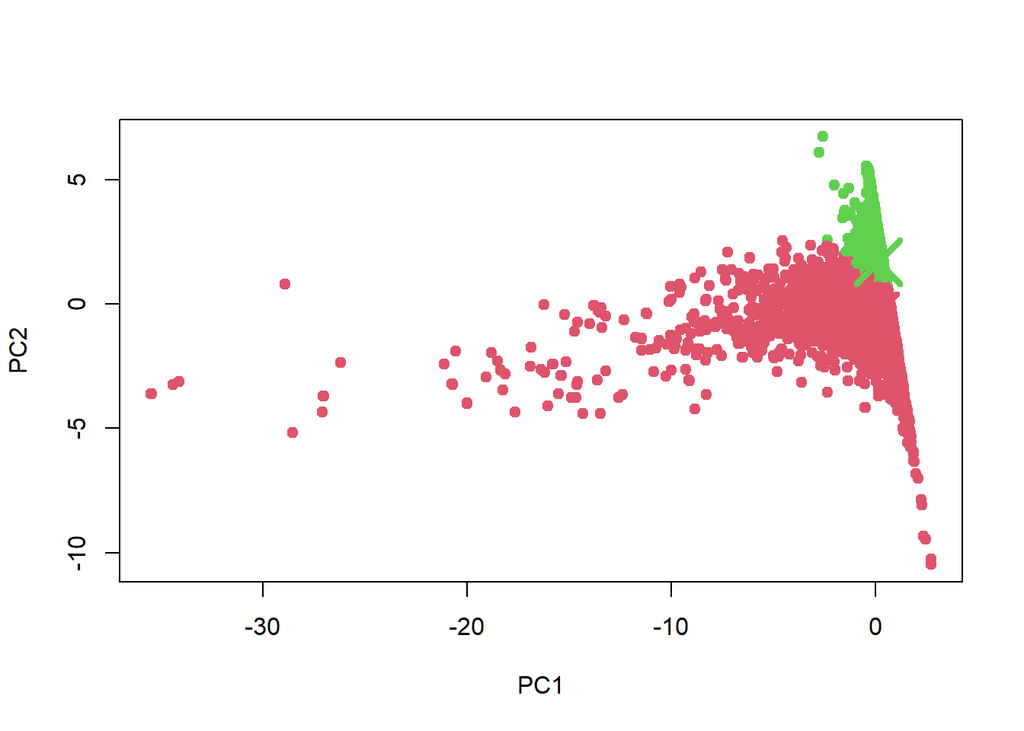

Vemos los dos grupos que se han generado, el verde y el rosa. Ahora vamos a ir iterando hasta que se estabilicen los clústeres.

```r
X_pca$dist_centroid <- apply(X_pca[, 3:(2 + K)], 1, min)
head(X_pca)
```

```
##           PC1        PC2 distancia1 distancia2 cluster dist_centroid
## 1   0.3467795  0.3573941  0.3799283  0.5781359       1     0.3799283
## 2 -15.8129542 -2.4020199 16.4229015 16.5712950       1    16.4229015
## 3   0.3103740  0.2929278  0.4423679  0.6472848       1     0.4423679
## 4   0.4865715  0.3904216  0.3885856  0.5446099       1     0.3885856
## 5  -0.1657911  0.5328196  0.5147777  0.7080174       1     0.5147777
## 6   0.6877414 -0.9366709  1.7146503  1.8867181       1     1.7146503
```

Comprobamos la varianza total de nuestros clústeres

```r
sum(X_pca$dist_centroid^2)
```

```
## [1] 122732.4
```

Vemos que nuestra varianza es alta, vamos a ir iterando y viendo como se reduce.

- Iteración 2:

Antes de proceder a ella vamos a fijar un epsilon, cuando la resta entre la vaianza total de una iteración no supere a este epsilon en la siguiente pararemos.

```r
epsilon = 10
var_ant <- sum(X_pca$dist_centroid^2)

for(i in 1:K){
  txt <- paste("X_pca$distancia",
               i,
               "<- sqrt((X_pca$PC1 - centroides$PC1[",
               i,
               "])^2 + (X_pca$PC2 - centroides$PC2[",
               i,
               "])^2)",
               sep = "")
  eval(parse(text = txt))
}
head(X_pca)
```

```
##           PC1        PC2 distancia1 distancia2 cluster dist_centroid
## 1   0.3467795  0.3573941  0.9083859   1.359320       1     0.3799283
## 2 -15.8129542 -2.4020199 15.8987444  16.448884       1    16.4229015
## 3   0.3103740  0.2929278  0.8346320   1.417476       1     0.4423679
## 4   0.4865715  0.3904216  1.0031462   1.357990       1     0.3885856
## 5  -0.1657911  0.5328196  1.0098163   1.198173       1     0.5147777
## 6   0.6877414 -0.9366709  0.8590345   2.694954       1     1.7146503
```

```r
X_pca$cluster <- apply(X_pca[, 3:(2 + K)], 1, which.min)
head(X_pca)
```

```
##           PC1        PC2 distancia1 distancia2 cluster dist_centroid
## 1   0.3467795  0.3573941  0.9083859   1.359320       1     0.3799283
## 2 -15.8129542 -2.4020199 15.8987444  16.448884       1    16.4229015
## 3   0.3103740  0.2929278  0.8346320   1.417476       1     0.4423679
## 4   0.4865715  0.3904216  1.0031462   1.357990       1     0.3885856
## 5  -0.1657911  0.5328196  1.0098163   1.198173       1     0.5147777
## 6   0.6877414 -0.9366709  0.8590345   2.694954       1     1.7146503
```

```r
centroides <- aggregate(cbind(PC1, PC2) ~ cluster,
                        data = X_pca,
                        mean)
centroides
```

```
##   cluster         PC1        PC2
## 1       1  0.01127178 -0.6643978
## 2       2 -0.02451000  1.4447035
```

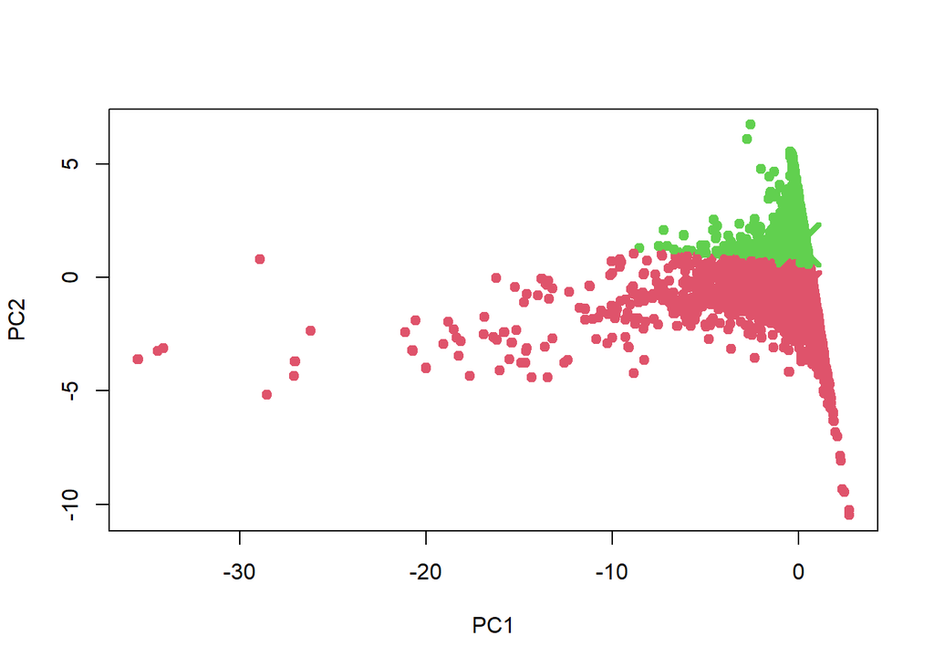

```r
X_pca$dist_centroid <- apply(X_pca[, 3:(2 + K)], 1, min)
head(X_pca)
```

```
##           PC1        PC2 distancia1 distancia2 cluster dist_centroid
## 1   0.3467795  0.3573941  0.9083859   1.359320       1     0.9083859
## 2 -15.8129542 -2.4020199 15.8987444  16.448884       1    15.8987444
## 3   0.3103740  0.2929278  0.8346320   1.417476       1     0.8346320
## 4   0.4865715  0.3904216  1.0031462   1.357990       1     1.0031462
## 5  -0.1657911  0.5328196  1.0098163   1.198173       1     1.0098163
## 6   0.6877414 -0.9366709  0.8590345   2.694954       1     0.8590345
```

Comprobamos la varianza total de nuestros clústeres:

```r
sum(X_pca$dist_centroid^2)
```

```
## [1] 88850.3
```

Comprobamos nuestro criterio de parada:

```r
var_ant - sum(X_pca$dist_centroid^2) < epsilon
```

```
## [1] FALSE
```

Vemos que no se cumple, por lo que seguimos iterando el proceso. A partir de ahora solo mostraremos el gráfico, la varianza total y si se cumple o no la condición.

- Iteración 3:

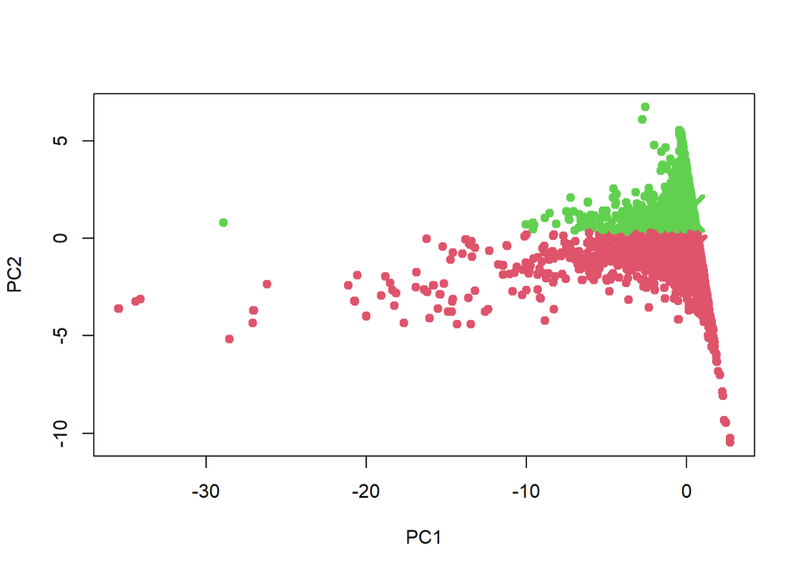

```r
X_pca$dist_centroid <- apply(X_pca[, 3:(2 + K)], 1, min)
sum(X_pca$dist_centroid^2)
```

```
## [1] 86745.03
```

```r
var_ant - sum(X_pca$dist_centroid^2) < epsilon
```

```
## [1] FALSE
```

Sigue sin cumplirse, así que iteraremos hasta que lo haga.

- Iteración 4:

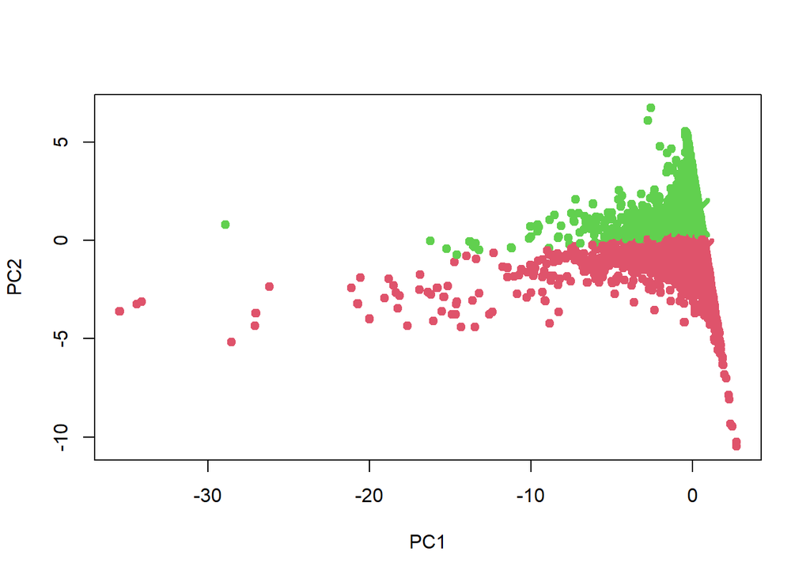

```r
X_pca$dist_centroid <- apply(X_pca[, 3:(2 + K)], 1, min)
sum(X_pca$dist_centroid^2)
```

```
## [1] 85821.99
```

```r
var_ant - sum(X_pca$dist_centroid^2) < epsilon
```

```
## [1] FALSE
```

- Iteración 5:

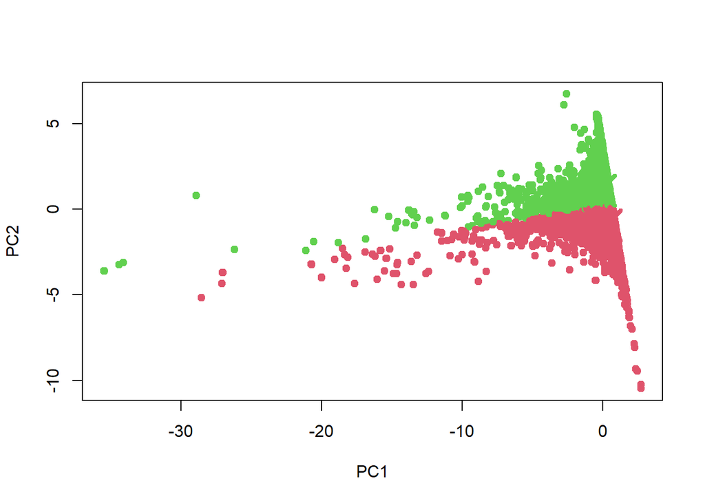

```r
X_pca$dist_centroid <- apply(X_pca[, 3:(2 + K)], 1, min)
sum(X_pca$dist_centroid^2)
```

```
## [1] 85297.4
```

```r
var_ant - sum(X_pca$dist_centroid^2) < epsilon
```

```
## [1] FALSE
```

- Iteración 6:

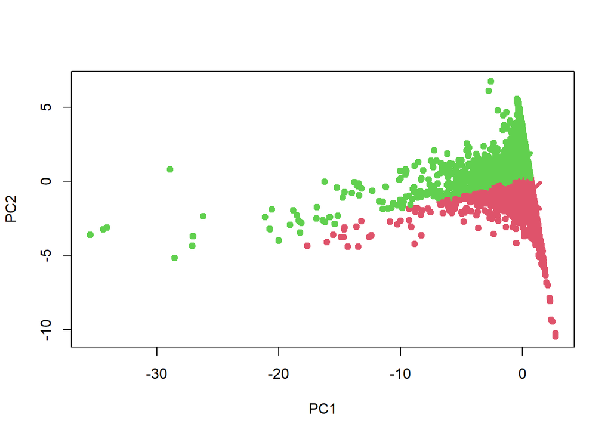

```r
X_pca$dist_centroid <- apply(X_pca[, 3:(2 + K)], 1, min)
sum(X_pca$dist_centroid^2)
```

```
## [1] 84712.28
```

```r
var_ant - sum(X_pca$dist_centroid^2) < epsilon
```

```
## [1] FALSE
```

- Iteración 7:

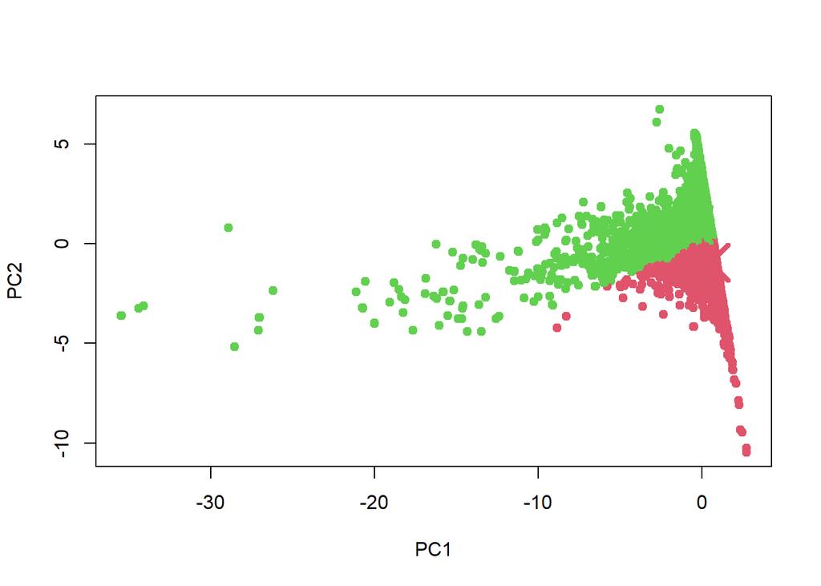

```r
X_pca$dist_centroid <- apply(X_pca[, 3:(2 + K)], 1, min)
sum(X_pca$dist_centroid^2)
```

```
## [1] 83377.68
```

```r
var_ant - sum(X_pca$dist_centroid^2) < epsilon
```

```
## [1] FALSE
```

- Iteración 8

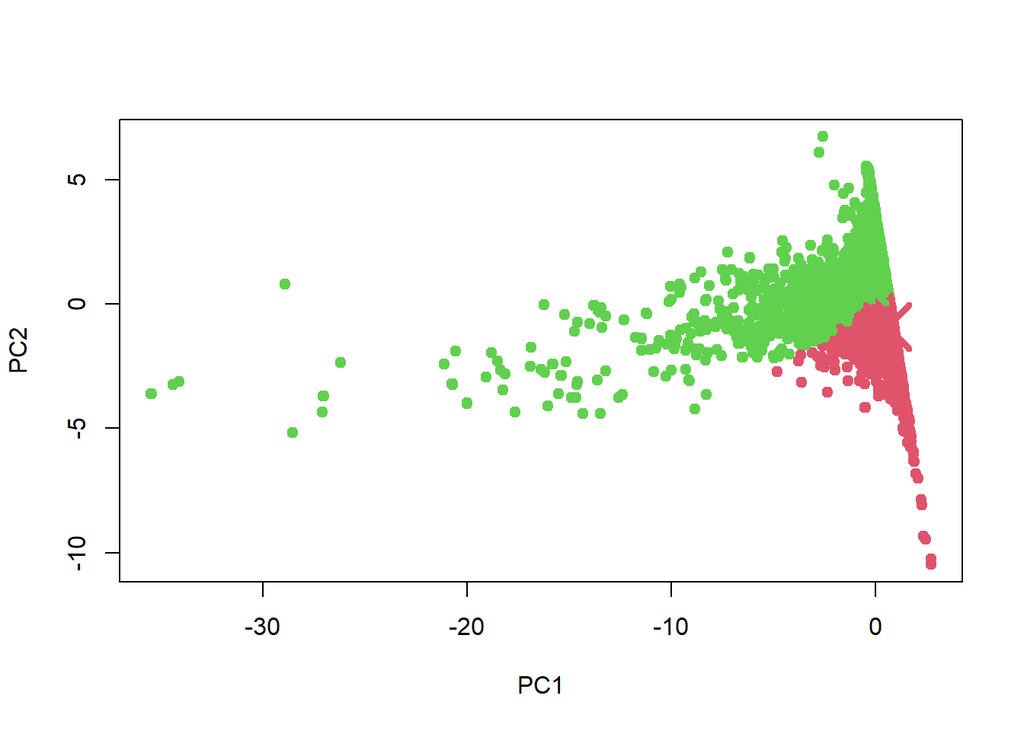

```r
X_pca$dist_centroid <- apply(X_pca[, 3:(2 + K)], 1, min)
sum(X_pca$dist_centroid^2)
```

```
## [1] 82564.09
```

```r
var_ant - sum(X_pca$dist_centroid^2) < epsilon
```

```
## [1] FALSE
```

- Iteración 9

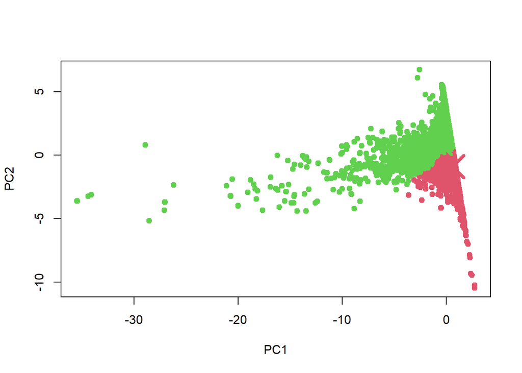

```r
X_pca$dist_centroid <- apply(X_pca[, 3:(2 + K)], 1, min)
sum(X_pca$dist_centroid^2)
```

```
## [1] 82460.72
```

```r
var_ant - sum(X_pca$dist_centroid^2) < epsilon
```

```
## [1] FALSE
```

- Iteración 10

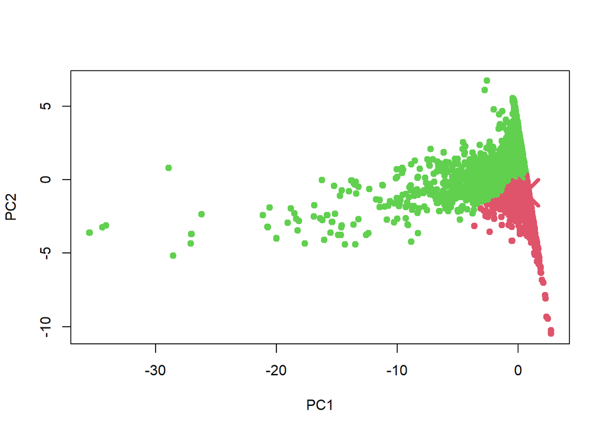

```r
X_pca$dist_centroid <- apply(X_pca[, 3:(2 + K)], 1, min)
sum(X_pca$dist_centroid^2)
```

```
## [1] 82444.01
```

```r
var_ant - sum(X_pca$dist_centroid^2) < epsilon
```

```
## [1] FALSE
```

- Iteración 11

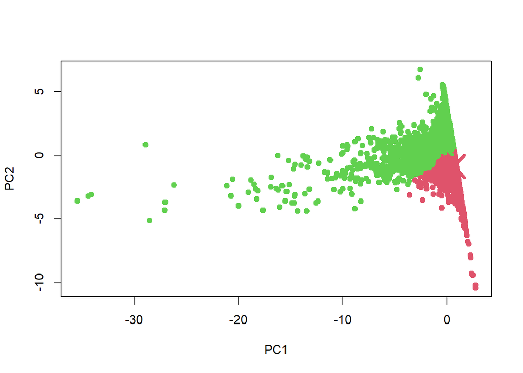

```r
X_pca$dist_centroid <- apply(X_pca[, 3:(2 + K)], 1, min)
sum(X_pca$dist_centroid^2)
```

```
## [1] 82437.98
```

```r
var_ant - sum(X_pca$dist_centroid^2) < epsilon
```

```
## [1] TRUE
```

Como podemos comprobar, nuestro criterio de parada se ha cumplido, por lo tanto vamos a parar.

Los grupos generado finales son:

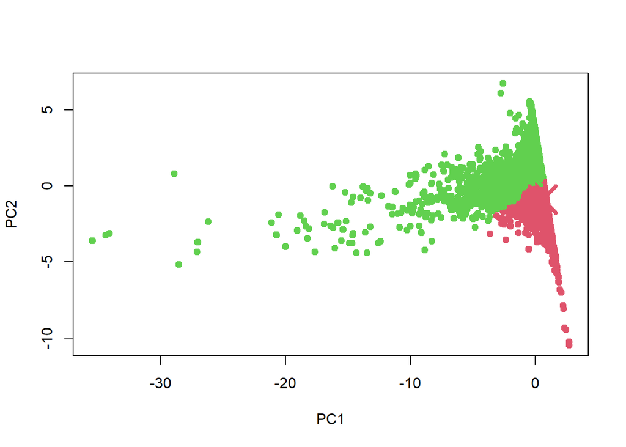

Ahora vamos a utilizar la función “kmeans” y comparar resultados.

```r
datos_km <- kmeans(X_pca[, 1:2], 2, nstart = 1e3)
```

Calculamos la inercia del modelo.

```r
datos_km$tot.withinss
```

```
## [1] 67768.45
```

Vemos que es menor que la que hemos conseguido nosotros de manera artesanal.

Mostramos los resultados:

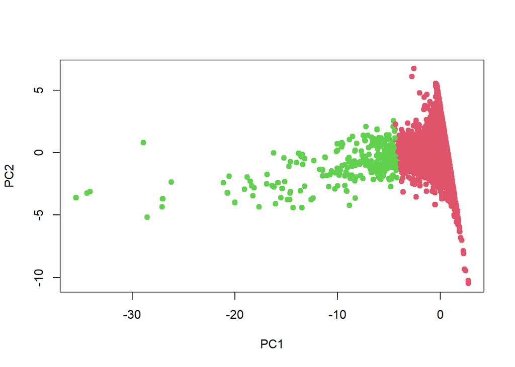

Vemos que los grupos se han generado divididos por los valores de PC1, es decir, los libros con más valoraciones o más populares de los que no lo son. Si recordamos, en nuestro otro caso se dividían por los valores de PC2, dividiendo grupos de libros con valoraciones más altas, frente a los que tienen valoraciones más bajas.

## 5. Conclusiones

Trabajo terminado, como último apartado vamos, de una manera muy breve, a concluir los resultados conseguidos.

Primero, no solo hemos conseguido familiarizarnos mejor con el entorno de RStudio, crenando proyectos y usando diferentes librerías, sino que hemos podido mejorar y desarrollar nuestras habilidades manejando R.

Segundo, hemos tratado unos datos con los que no habíamos trabajado previamente. Con ello, hemos aprendido a manejarnos con datos desconocidos y con un tema que nos parece interesante: el mundo de la literatura.

Por último, hemos podido aplicar todos los conceptos vistos en la asignatura. Haciendo un repaso por su contenido teórico y pudiendo aplicarlo a nuestros datos, logrando conclusiones interesantes.

Gracias por la oportunidad realizando este trabajo, ha sido un placer.